# Quality control

2017-06-26

```r
library(DESeq2)
library(bcbioRnaseq)

downloads()

source("setup.R")  # modify parameters before exec this line

# Get [tximport()]-generated counts from run
txi <- bcbio(bcb, "tximport")

# colData metadata
colData <- colData(bcb)

# Design formula
design <- formula(~ 1)
```

# Overview

```r
> metadata_table(bcb)
```

Sample metadata

| date | gender | genotype | replicate | treatment |
| --- | --- | --- | --- | --- |
| NA | female | wt | NA | untreated |
| NA | female | wt | NA | untreated |
| NA | female | wt | NA | untreated |
| NA | female | wt | NA | untreated |
| NA | female | wt | NA | untreated |
| NA | male | wt | NA | untreated |
| NA | male | wt | NA | untreated |
| NA | male | wt | NA | untreated |
| NA | male | wt | NA | cde |
| NA | male | wt | NA | cde |
| 12-29-15 | male | wt | 1 | ccl4 |
| 12-1-15 | male | wt | 2 | ccl4 |
| 12-29-15 | male | wt | 3 | ccl4 |
| 12-1-15 | male | wt | 4 | ccl4 |
| 12-29-15 | male | wt | 5 | ccl4 |
| 10-15-15 | male | wt | 1 | untreated |
| 10-15-15 | male | wt | 2 | untreated |
| 10-2-15 | male | wt | 3 | untreated |
| 12-1-15 | male | wt | 4 | untreated |
| 10-2-15 | male | wt | 5 | untreated |
| 5-11-16 | male | yaptaz | 1 | ccl4 |
| 5-12-16 | male | yaptaz | 2 | ccl4 |
| 5-9-16 | male | yaptaz | 3 | ccl4 |
| 10-29-15 | male | yaptaz | 1 | untreated |
| 10-29-15 | male | yaptaz | 2 | untreated |
| 5-31-16 | male | yaptaz | 3 | untreated |
| 5-31-16 | male | yaptaz | 4 | untreated |

```r
> dds <- DESeqDataSetFromTximport(txi = txi, colData = colData, design = design) %>%
+     DESeq
> save_data(dds, dir = data_out)
> resultsNames(dds)
> sizeFactors(dds)
```

```r
> raw_counts <- counts(dds, normalized = FALSE)
```

[output not shown]

```r
> normalized_counts <- counts(dds, normalized = TRUE)
```

[output not shown]

```r
> tpm <- tpm(bcb)
> save_data(raw_counts, normalized_counts, tpm, dir = data_out)
```

[output not shown]

```r
> write_counts(raw_counts, normalized_counts, tpm, dir = count_out)
```

[output not shown]

```r
> rld <- rlog(dds)
```

[output not shown]

```r
> tmm <- tmm(raw_counts)
```

[output not shown]

```r
> vsd <- varianceStabilizingTransformation(dds)
```

[output not shown]

# [DESeq2](https://bioconductor.org/packages/release/bioc/html/DESeq2.html) fit modeling

```r
> plot_mean_sd(dds, rld, vsd)
```

[output not shown]

[output not shown]

```
## Error in eval(lhs, parent, parent): object 'dds' not found
```

## Dispersion

```r
> plotDispEsts(dds)
```

[output not shown]

[output not shown]

```
## Error in plotDispEsts(dds): object 'dds' not found
```

# Read metrics

## Total reads

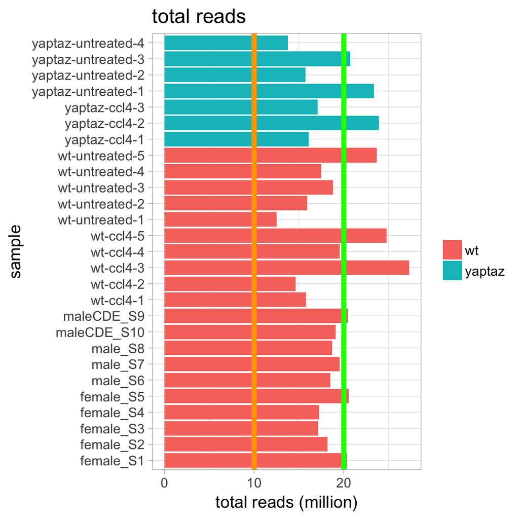

```r
> plot_total_reads(bcb)
```

## Mapped reads

The number of mapped reads should correspond to the number of total reads.

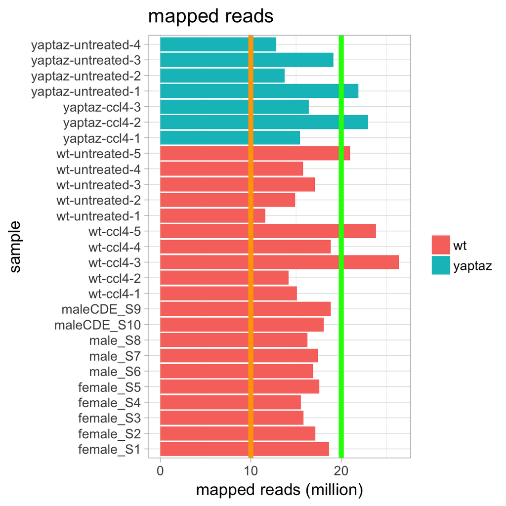

```r
> plot_mapped_reads(bcb)
```

## Mapping rate

The genomic mapping rate represents the percentage of reads mapping to the reference genome. Low mapping rates are indicative of sample contamination, poor sequencing quality or other artifacts.

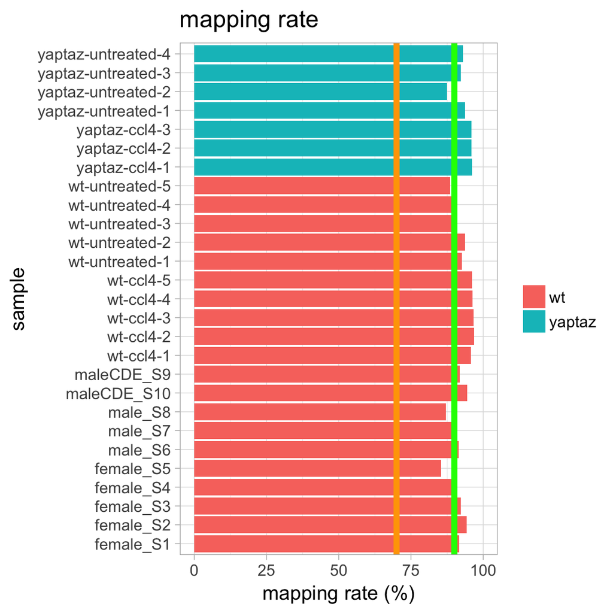

```r
> plot_mapping_rate(bcb)
```

## Number of genes detected

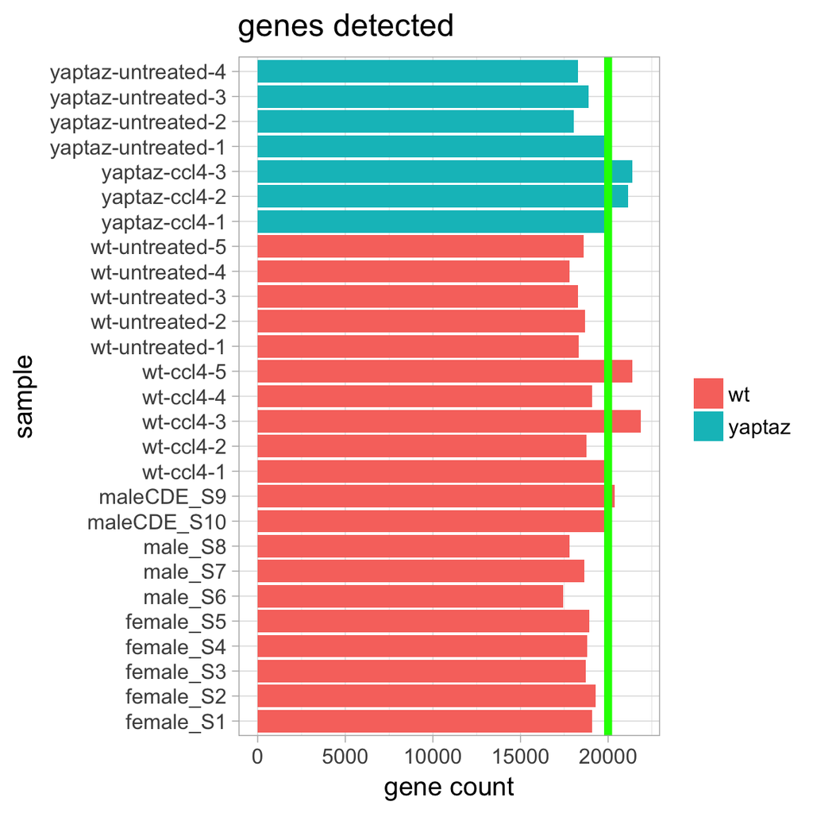

```r
> plot_genes_detected(bcb)
```

## Gene detection saturation

We should observe a linear trend in the number of genes detected with the number of mapped reads, which indicates that the sample input was not overloaded.

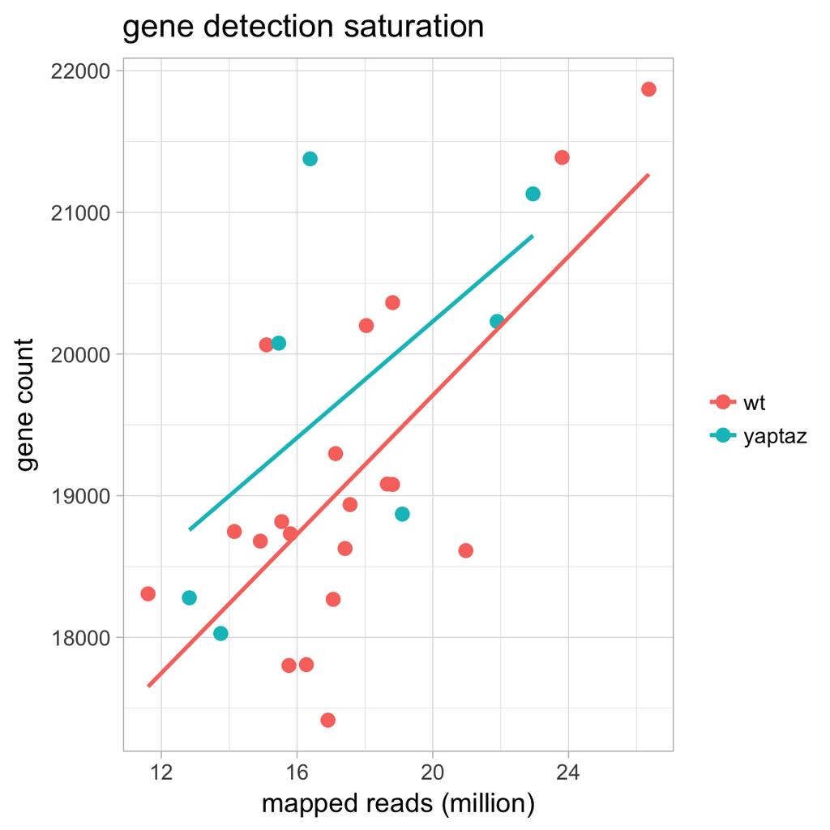

```r
> plot_gene_detection_saturation(bcb)
```

## Exonic mapping rate

Ideally, at least 60% of total reads should map to exons.

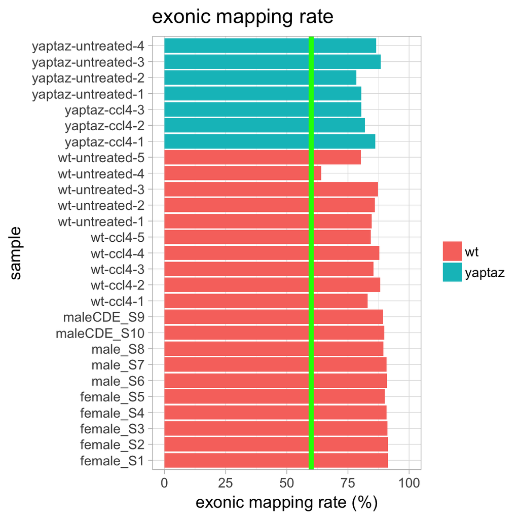

```r
> plot_exonic_mapping_rate(bcb)
```

## Intronic mapping rate

The majority of reads should map to exons and not introns.

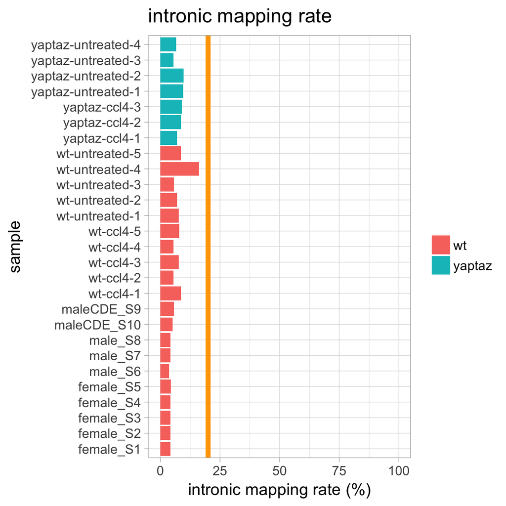

```r
> plot_intronic_mapping_rate(bcb)
```

## rRNA mapping rate

Samples should have a ribosomal RNA (rRNA) contamination rate below 10%.

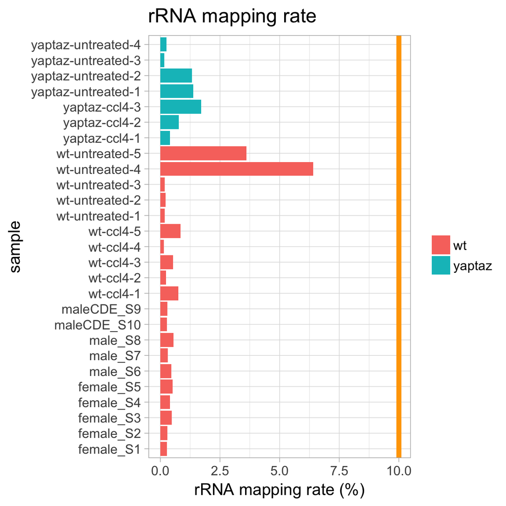

```r
> plot_rrna_mapping_rate(bcb)
```

## Counts per gene

Generally, we expect similar count spreads for all genes between samples unless the library sizes or total RNA expression are different. The log10 TMM-normalized counts per gene normalization method (Robinson and Oshlack 2010) equates the overall expression levels of genes between samples under the assumption that the majority of them are not differentially expressed. Therefore, by normalizing for total RNA expression by sample, we expect the spread of the log10 TMM-normalized counts per gene to be similar for every sample.

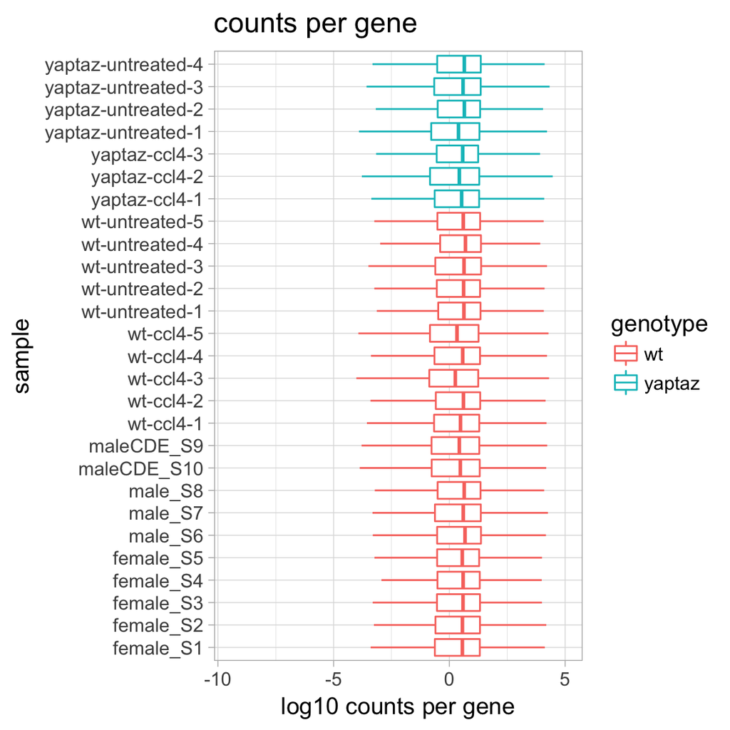

```r
> # Add intgroup option to change colors
> plot_counts_per_gene(bcb)
```

## Count density

Generally, we expect similar count spreads for all genes between samples unless the total expressed RNA per sample is different.

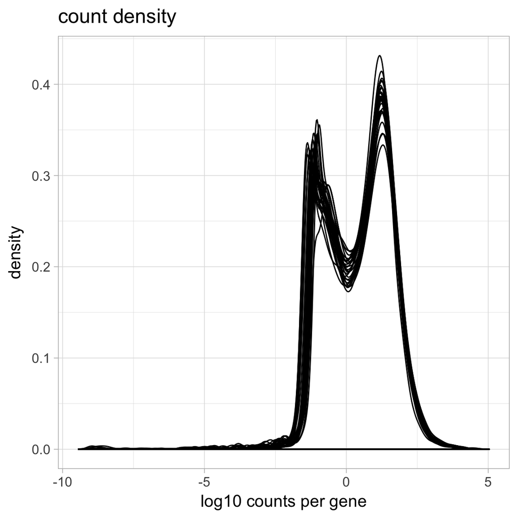

```r
> plot_count_density(bcb)
```

# Sample similarity analysis

Before performing similarity analysis, we transform counts to log2, which acts to minimize large differences in sequencing depth and helps normalize all samples to a similar dynamic range. For RNA-seq count data, variance increases with the mean. Logarithmic transformation of normalized count values with a small pseudocount will account for large variations seen between the highest expressing genes so that these genes won’t dominate the PCA plots. However, due to the strong noise among low count values due to Poisson, the general log2 transformation will amplify this noise, and instead, low count genes will now dominate the PCA plots. So instead, we use a transformation (`rlog()`) that gives similar results for high counts as a log2 transformation but also shrinks the values of low counts towards the genes’ average across samples. We do this with the `rlog()` function in the [DESeq2](https://bioconductor.org/packages/release/bioc/html/DESeq2.html) package (Love, Huber, and Anders 2014), which we will later use for differential gene expression analysis.

## Principal component analysis (PCA)

```r
> plot_pca(bcb, rld)
```

[output not shown]

[output not shown]

```
## Error in plotPCA(dt, intgroup = interesting_groups, returnData = TRUE, : object 'rld' not found
```

## Covariates correlation with PCs

```r
> plot_pca_covariates(bcb, rld)
```

[output not shown]

[output not shown]

```
## Error in eval(lhs, parent, parent): object 'rld' not found
```

## Hierarchical clustering

```r
> plot_correlation_heatmap(bcb, rld)
```

[output not shown]

[output not shown]

```
## Error in assay(dt): object 'rld' not found
```

# Methods

RNA-seq counts were generated by bcbio-nextgen and bcbioRnaseq using [salmon](https://combine-lab.github.io/salmon/) (Patro et al. 2017). Counts were imported into [R](https://www.r-project.org/) using [tximport](https://bioconductor.org/packages/release/bioc/html/tximport.html) (Soneson, Love, and Robinson 2015) and [DESeq2](https://bioconductor.org/packages/release/bioc/html/DESeq2.html) (Love, Huber, and Anders 2014). Gene annotations were obtained from [Ensembl](http://useast.ensembl.org/Mus_musculus/Info/Index). Plots were generated by [ggplot2](http://ggplot2.org/) (Wickham 2009). Heatmaps were generated by [pheatmap](https://cran.r-project.org/web/packages/pheatmap/index.html) (Kolde 2015).

# References

Jolliffe, Ian. 2002. *Principal component analysis*. Wiley Online Library.

Kolde, Raivo. 2015. *pheatmap: Pretty Heatmaps*.

Love, Michael I, Wolfgang Huber, and Simon Anders. 2014. “Moderated estimation of fold change and dispersion for RNA-seq data with DESeq2.” 15 (12): 550.

Robinson, Mark D, and Alicia Oshlack. 2010. “A scaling normalization method for differential expression analysis of RNA-seq data.” 11 (3): R25.

Soneson, Charlotte, Michael I Love, and Mark D Robinson. 2015. “Differential analyses for RNA-seq: transcript-level estimates improve gene-level inferences.” *F1000Research* 4: 1521.

Wickham, Hadley. 2009. *ggplot2: Elegant Graphics for Data Analysis.* Springer New York.